# PCA_example

Seo eunyu

2021 10 21

# 0. 패키지 불러오기

```r
# 패키지 불러오기
library(tidyverse)
library(FactoMineR)
library(factoextra)
```

# A. 모집단 공분산 행렬

```r
S=matrix(c(10000,60,60,1), nrow=2)

# a. S에 대응하는 R 구하기
invDs<-diag(1/sqrt(diag(S)))
R<-invDs %*% S %*% invDs
R
```

```
##      [,1] [,2]
## [1,]  1.0  0.6
## [2,]  0.6  1.0
```

```r
# b. S를 이용한 주성분 분석
eig_S<-eigen(S)
# 아이겐 벡터
V_S<-eig_S$vectors
V_S
```

```
##              [,1]         [,2]
## [1,] -0.999981998  0.006000276
## [2,] -0.006000276 -0.999981998
```

```r
#아이겐 값
L_S<-diag(eig_S$values)
L_S
```

```
##          [,1]     [,2]
## [1,] 10000.36 0.000000
## [2,]     0.00 0.639977
```

```r
# c. R을 활용한 주성분 분석
eig_R<-eigen(R)
# 아이겐 벡터
V_R<-eig_R$vectors
V_R
```

```
##           [,1]       [,2]
## [1,] 0.7071068 -0.7071068
## [2,] 0.7071068  0.7071068
```

```r
#아이겐 값
L_R<-diag(eig_R$values)
L_R
```

```
##      [,1] [,2]
## [1,]  1.6  0.0
## [2,]  0.0  0.4
```

```r
# d. S를 이용한 주성분분석과 R을 이용한 주성분 분석 비교
eig_S
```

```
## eigen() decomposition
## $values
## [1] 10000.360023     0.639977
##
## $vectors
##              [,1]         [,2]
## [1,] -0.999981998  0.006000276
## [2,] -0.006000276 -0.999981998
```

```r
eig_R
```

```
## eigen() decomposition
## $values
## [1] 1.6 0.4
##
## $vectors
##           [,1]       [,2]
## [1,] 0.7071068 -0.7071068
## [2,] 0.7071068  0.7071068
```

=> R에 의한 주성분과 S에 의한 주성분이 설명하는 분산의 양은 다르며, 각 주성분의 계수도 다르다.

=> R은 척도가 변하지 않으므로, R에 의한 주성분도 변하지 않는다. 또한 R에 의한 주성분은 유일하지 않다.

# B. 미국 범죄통계

```r
# 데이터 불러오기 및 데이터 정리
DF1<-read.csv('crime-kr.csv')
crime<-DF1[2:8]
row.names(crime)<-DF1$state
crime
```

```
##                murder rape robbery assault burglary larceny   auto
## Alabama          14.2 25.2    96.8   278.3   1135.5  1881.9  280.7
## Alaska           10.8 51.6    96.8   284.0   1331.7  3369.8  753.3
## Arizona           9.5 34.2   138.2   312.3   2346.1  4467.4  439.5
## Arkansas          8.8 27.6    83.2   203.4    972.6  1862.1  183.4
## California       11.5 49.4   287.0   358.0   2139.4  3499.8  663.5
## Colorado          6.3 42.0   170.7   292.9   1935.2  3903.2  477.1
## Connecticut       4.2 16.8   129.5   131.8   1346.0  2620.7  593.2
## Delaware          6.0 24.9   157.0   194.2   1682.6  3678.4  467.0
## Florida          10.2 39.6   187.9   449.1   1859.9  3840.5  351.4
## Georgia          11.7 31.1   140.5   256.5   1351.1  2170.2  297.9
## Hawaii            7.2 25.5   128.0    64.1   1911.5  3920.4  489.4
## Idaho             5.5 19.4    39.6   172.5   1050.8  2599.6  237.6
## Illinois          9.9 21.8   211.3   209.0   1085.0  2828.5  528.6
## Indiana           7.4 26.5   123.2   153.5   1086.2  2498.7  377.4
## Iowa              2.3 10.6    41.2    89.8    812.5  2685.1  219.9
## Kansas            6.6 22.0   100.7   180.5   1270.4  2739.3  244.3
## Kentucky         10.1 19.1    81.1   123.3    872.2  1662.1  245.4
## Louisiana        15.5 30.9   142.9   335.5   1165.5  2469.9  337.7
## Maine             2.4 13.5    38.7   170.0   1253.1  2350.7  246.9
## Maryland          8.0 34.8   292.1   358.9   1400.0  3177.7  428.5
## Massachusetts     3.1 20.8   169.1   231.6   1532.2  2311.3 1140.1
## Michigan          9.3 38.9   261.9   274.6   1522.7  3159.0  545.5
## Minnesota         2.7 19.5    85.9    85.8   1134.7  2559.3  343.1
## Mississippi      14.3 19.6    65.7   189.1    915.6  1239.9  144.4
## Missouri          9.6 28.3   189.0   233.5   1318.3  2424.2  378.4
## Montana           5.4 16.7    39.2   156.8    804.9  2773.2  309.2
## Nebraska          3.9 18.1    64.7   112.7    760.0  2316.1  249.1
## Nevada           15.8 49.1   323.1   355.0   2453.1  4212.6  559.2
## New Hampshire     3.2 10.7    23.2    76.0   1041.7  2343.9  293.4
## New Jersey        5.6 21.0   180.4   185.1   1435.8  2774.5  511.5
## New Mexico        8.8 39.1   109.6   343.4   1418.7  3008.6  259.5
## New York         10.7 29.4   472.6   319.1   1728.0  2782.0  745.8
## North Carolina   10.6 17.0    61.3   318.3   1154.1  2037.8  192.1
## North Dakota      0.9  9.0    13.3    43.8    446.1  1843.0  144.7
## Ohio              7.8 27.3   190.5   181.1   1216.0  2696.8  400.4
## Oklahoma          8.6 29.2    73.8   205.0   1288.2  2228.1  326.8
## Oregon            4.9 39.9   124.1   286.9   1636.4  3506.1  388.9
## Pennsylvania      5.6 19.0   130.3   128.0    877.5  1624.1  333.2
## Rhode Island      3.6 10.5    86.5   201.0   1489.5  2844.1  791.4
## South Carolina   11.9 33.0   105.9   485.3   1613.6  2342.4  245.1
## South Dakota      2.0 13.5    17.9   155.7    570.5  1704.4  147.5
## Tennessee        10.1 29.7   145.8   203.9   1259.7  1776.5  314.0
## Texas            13.3 33.8   152.4   208.2   1603.1  2988.7  397.6
## Utah              3.5 20.3    68.8   147.3   1171.6  3004.6  334.5
## Vermont           1.4 15.9    30.8   101.2   1348.2  2201.0  265.2
## Virginia          9.0 23.3    92.1   165.7    986.2  2521.2  226.7
## Washington        4.3 39.6   106.2   224.8   1605.6  3386.9  360.3
## West Virginia     6.0 13.2    42.2    90.9    597.4  1341.7  163.3
## Wisconsin         2.8 12.9    52.2    63.7    846.9  2614.2  220.7
## Wyoming           5.4 21.9    39.7   173.9    811.6  2772.2  282.0
```

```r
# 상관행렬 R로 분석하기
Mprcomp_crime<-prcomp(crime, center=TRUE, scale=TRUE)
summary(Mprcomp_crime)
```

```
## Importance of components:
##                           PC1    PC2    PC3    PC4     PC5     PC6     PC7
## Standard deviation     2.0285 1.1130 0.8519 0.5625 0.50791 0.47121 0.35222
## Proportion of Variance 0.5878 0.1770 0.1037 0.0452 0.03685 0.03172 0.01772
## Cumulative Proportion  0.5878 0.7648 0.8685 0.9137 0.95056 0.98228 1.00000
```

```r
# 주성분계수 개수 정하기
vrexp<-data.frame(
  pc=1:length(Mprcomp_crime$sdev), #루트 람다
  eigval=Mprcomp_crime$sdev^2, # 람다. 아이겐값
  prop=Mprcomp_crime$sdev^2/sum(Mprcomp_crime$sdev^2), # 주성분 별 비율
  cuml=cumsum(Mprcomp_crime$sdev^2)/sum(Mprcomp_crime$sdev^2)) # 전체 누적 비율
vrexp
```

```
##   pc    eigval       prop      cuml
## 1  1 4.1149595 0.58785136 0.5878514
## 2  2 1.2387218 0.17696026 0.7648116
## 3  3 0.7258166 0.10368809 0.8684997
## 4  4 0.3164320 0.04520458 0.9137043
## 5  5 0.2579745 0.03685349 0.9505578
## 6  6 0.2220395 0.03171992 0.9822777
## 7  7 0.1240561 0.01772229 1.0000000
```

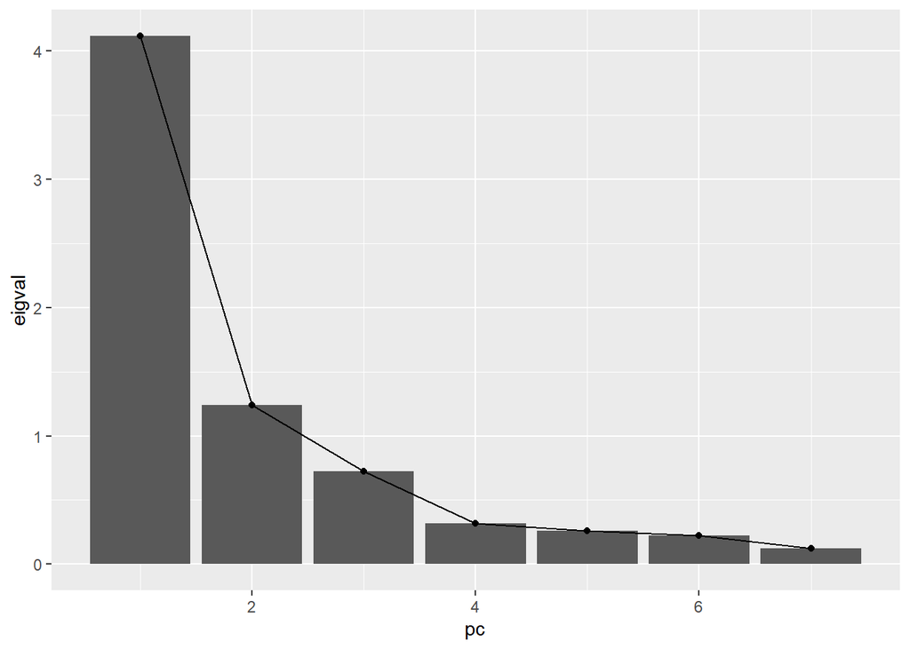

```r
# 스크리 도표 그리기 (ggbiplot)
library(ggfortify)
ggplot(vrexp, aes(x=pc, y=eigval))+
  geom_col()+geom_point()+ geom_line()
```

=> 사회과학 쪽에서는 아이겐 값이 1이 넘는 것만 주성분으로 사용한다. 따라서 주성분 개수는 2개 이다.

=> 여기서는 주성분 개수를 “2개”로 정하겠다.

```r
# 주성분 해석하기
Mprcomp_crime$rotation
```

```
##                 PC1         PC2         PC3         PC4         PC5         PC6
## murder   -0.3002792 -0.62917444  0.17824530 -0.23211411  0.53812286  0.25911677
## rape     -0.4317594 -0.16943512 -0.24419758  0.06221567  0.18847069 -0.77327066
## robbery  -0.3968755  0.04224698  0.49586087 -0.55798926 -0.51997683 -0.11438481
## assault  -0.3966517 -0.34352815 -0.06950972  0.62980445 -0.50665138  0.17236294
## burglary -0.4401572  0.20334059 -0.20989509 -0.05755491  0.10103335  0.53598716
## larceny  -0.3573595  0.40231912 -0.53923144 -0.23488987  0.03009857  0.03940645
## auto     -0.2951768  0.50242093  0.56838373  0.41923832  0.36975317 -0.05729763
##                   PC7
## murder    0.267592768
## rape     -0.296485476
## robbery  -0.003902681
## assault   0.191744586
## burglary -0.648117080
## larceny   0.601690040
## auto      0.147046259
```

#### PC2 해석하기

=> 강도 - 빈집털이 - 절도 - 차량절도 끼리 상관관계가 있고, 살인 - 폭행 - 성범죄를 저지른 사람끼리 상관 관계가 있다. (엄밀히 말하면 성범죄는 0.16으로 비교적 다른 범죄들과 상관관계가 없는 편이다.

=> 강도 - 빈집털이 - 절도 - 차량절도 처럼 재산 및 금품 관련 범죄 중 1개를 저지른 사람은 다른 재산 및 금품 관련 저지를 가능성이 높지만 그것과 대비해서 살인 - 폭행 - 성범죄는 저지르지 않는 것을 알 수 있다.

```r
# 주성분 점수 확인
Mprcomp_crime$x
```

```
##                        PC1           PC2         PC3         PC4         PC5
## Alabama         0.04988023 -2.096102e+00  0.50164458  0.25098524  0.49848609
## Alaska         -2.42151498  1.665230e-01 -0.06973119  1.16047160  1.47005070
## Arizona        -3.01413828  8.449451e-01 -1.75195019 -0.11621184  0.28021091
## Arkansas        1.05441043 -1.345440e+00 -0.01833744  0.02153636  0.02268823
## California     -4.28380373  1.431874e-01  0.27615493  0.02512179  0.05793110
## Colorado       -2.50929252  9.165964e-01 -1.15158038  0.11260250 -0.16923194
## Connecticut     0.54132949  1.501230e+00  0.78388522  0.08619036  0.18488613
## Delaware       -0.96458065  1.296743e+00 -0.52586471 -0.41732439 -0.01872452
## Florida        -3.11175398 -6.039167e-01 -1.21540527  0.49507519 -0.81966597
## Georgia        -0.49040760 -1.380788e+00  0.24462945 -0.06247538  0.20210113
## Hawaii         -0.82313133  1.823918e+00 -0.78175736 -1.18025053  1.09329238
## Idaho           1.43245398 -8.005893e-03 -0.63413821  0.12190874 -0.01495163
## Illinois       -0.51290250  9.423047e-02  1.12119645 -0.43124848  0.01826194
## Indiana         0.49989550  2.603339e-05  0.24332970 -0.26745416  0.24919453
## Iowa            2.58156193  8.247534e-01 -0.51547796 -0.30084619 -0.29187060
## Kansas          0.63406694 -2.804164e-02 -0.49572784 -0.32463057 -0.14645424
## Kentucky        1.72690862 -1.146632e+00  0.65776657 -0.38310549  0.55866683
## Louisiana      -1.12020258 -2.083274e+00  0.36745785  0.20339604  0.35921867
## Maine           1.82631078  5.787849e-01 -0.53241417  0.33763421 -0.47705886
## Maryland       -2.18279829 -1.947420e-01  0.38165207 -0.18255842 -1.35485342
## Massachusetts  -0.97843898  2.631054e+00  2.54224977  1.81310279  0.44073863
## Michigan       -2.27333440  1.548736e-01  0.53567439 -0.33238365 -0.24676406
## Minnesota       1.55434237  1.056437e+00 -0.14622654 -0.31594129 -0.01756913
## Mississippi     1.50735805 -2.546713e+00  0.70369299 -0.20981051  0.70955463
## Missouri       -0.55636649 -5.585112e-01  0.56335772 -0.30672861 -0.15162777
## Montana         1.66801293  2.709918e-01 -0.36800478  0.14796246  0.09217706
## Nebraska        2.15070745  2.257386e-01 -0.11051747 -0.16839508 -0.16360892
## Nevada         -5.26698533 -2.526192e-01 -0.30241384 -0.98007717  0.35721552
## New Hampshire   2.46562286  8.250300e-01 -0.20949060 -0.08806861  0.19073674
## New Jersey     -0.21787382  9.642088e-01  0.60387377 -0.19902361 -0.24449503
## New Mexico     -1.21417094 -9.507561e-01 -1.07275735  0.53541037 -0.34151634
## New York       -3.45248018  4.328929e-01  2.73661480 -0.99365715 -1.26801887
## North Carolina  0.69925167 -1.670272e+00 -0.09040800  0.65017870 -0.29794569
## North Dakota    3.96407765  3.876708e-01 -0.08603135 -0.18059461 -0.38234514
## Ohio           -0.23953033  9.052676e-02  0.45964182 -0.57002058 -0.13419123
## Oklahoma        0.32136304 -6.242883e-01 -0.12134307  0.26264111  0.43319574
## Oregon         -1.44900212  5.860252e-01 -1.24505345  0.41818238 -0.35116510
## Pennsylvania    1.72006943 -1.958980e-01  1.00917828 -0.19284530 -0.21512326
## Rhode Island    0.20155515  2.146576e+00  0.95680021  1.13035094  0.31612154
```

[output cut: 47 more lines]

```
## Oklahoma       -0.13096797 -0.42570283
## Oregon         -0.58967012 -0.23749645
## Pennsylvania   -0.34819296 -0.38227856
## Rhode Island    0.99986695  0.29751353
## South Carolina  0.69113773 -0.22241020
## South Dakota   -0.32213205 -0.03645034
## Tennessee      -0.21754074 -0.68230130
## Texas           0.16773290 -0.01221443
## Utah           -0.03047365  0.18069306
## Vermont         0.31074732 -0.91332978
## Virginia       -0.10013605  0.30801951
## Washington     -0.72807967 -0.46312237
## West Virginia  -0.16642801 -0.20531676
## Wisconsin      -0.05771121  0.25350331
## Wyoming        -0.37797920  0.62723036
```

```r
# 주성분 1의 최고 점수를 받은 주
sort(Mprcomp_crime$x[,1], decreasing=TRUE)[1]
```

```
## North Dakota
##     3.964078
```

```r
# 주성분 1의 최저 점수를 받은 주
sort(Mprcomp_crime$x[,1], decreasing=FALSE)[1]
```

```
##    Nevada
## -5.266985
```

```r
# 주성분 2의 최고 점수를 받은 주
sort(Mprcomp_crime$x[,2], decreasing=TRUE)[1]
```

```
## Massachusetts
##      2.631054
```

```r
# 주성분 2의 최저 점수를 받은 주
sort(Mprcomp_crime$x[,2], decreasing=FALSE)[1]
```

```
## Mississippi
##   -2.546713
```

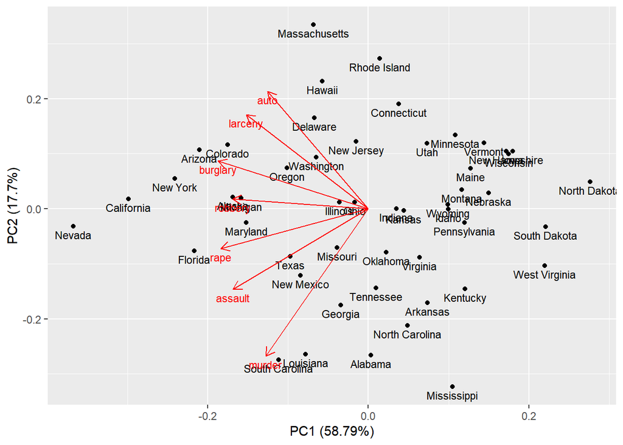

```r
# biplot 그리기
autoplot(Mprcomp_crime, data=crime,
         label=TRUE, label.size=3, label.vjust=1.5,
         loadings=TRUE, loadings.label=TRUE,
         loadings.label.size=3,loadings.label.vjust=1.5)
```

# C. olivetti 얼굴 인식

```r
# 데이터 불러오기
olivetti<-read.csv('olivetti_X.csv')
dim(olivetti) # 주성분 총 399개
```

```
## [1]  399 4096
```

```r
# 공분산행렬 S로 분석하기
Mprcomp_olivetti<-prcomp(olivetti, center=TRUE, scale=FALSE)
summary(Mprcomp_olivetti)
```

```
## Importance of components:
##                           PC1    PC2     PC3     PC4    PC5     PC6     PC7
## Standard deviation     4.3340 3.3314 2.51304 1.99011 1.6874 1.58169 1.38375
## Proportion of Variance 0.2375 0.1403 0.07984 0.05007 0.0360 0.03163 0.02421
## Cumulative Proportion  0.2375 0.3778 0.45762 0.50769 0.5437 0.57531 0.59952
##                            PC8     PC9    PC10    PC11    PC12   PC13   PC14
## Standard deviation     1.26237 1.24603 1.15158 1.12273 1.06586 0.9942 0.9537
## Proportion of Variance 0.02015 0.01963 0.01677 0.01594 0.01436 0.0125 0.0115
## Cumulative Proportion  0.61966 0.63929 0.65606 0.67199 0.68635 0.6988 0.7104
##                           PC15   PC16    PC17    PC18    PC19    PC20   PC21
## Standard deviation     0.91738 0.8805 0.85340 0.80374 0.77323 0.76960 0.7443
## Proportion of Variance 0.01064 0.0098 0.00921 0.00817 0.00756 0.00749 0.0070
## Cumulative Proportion  0.72099 0.7308 0.74000 0.74816 0.75572 0.76321 0.7702
##                           PC22    PC23    PC24    PC25    PC26    PC27    PC28
## Standard deviation     0.69731 0.68053 0.67191 0.65777 0.64903 0.63737 0.62708
## Proportion of Variance 0.00615 0.00585 0.00571 0.00547 0.00533 0.00514 0.00497
## Cumulative Proportion  0.77636 0.78222 0.78792 0.79339 0.79872 0.80386 0.80883
##                           PC29    PC30    PC31    PC32    PC33    PC34    PC35
## Standard deviation     0.60250 0.59083 0.56413 0.55177 0.53579 0.51369 0.50406
## Proportion of Variance 0.00459 0.00441 0.00402 0.00385 0.00363 0.00334 0.00321
## Cumulative Proportion  0.81342 0.81783 0.82185 0.82570 0.82933 0.83267 0.83588
##                           PC36    PC37    PC38    PC39    PC40   PC41    PC42
## Standard deviation     0.50059 0.49177 0.48591 0.47270 0.46554 0.4537 0.44876
## Proportion of Variance 0.00317 0.00306 0.00298 0.00282 0.00274 0.0026 0.00255
## Cumulative Proportion  0.83905 0.84210 0.84509 0.84791 0.85065 0.8533 0.85580
##                           PC43   PC44    PC45    PC46    PC47    PC48    PC49
## Standard deviation     0.44042 0.4354 0.42737 0.42356 0.41965 0.41790 0.40693
## Proportion of Variance 0.00245 0.0024 0.00231 0.00227 0.00223 0.00221 0.00209
## Cumulative Proportion  0.85825 0.8607 0.86296 0.86523 0.86745 0.86966 0.87175
##                           PC50    PC51    PC52    PC53    PC54    PC55    PC56
## Standard deviation     0.40223 0.39472 0.38964 0.38302 0.37672 0.37532 0.36961
## Proportion of Variance 0.00205 0.00197 0.00192 0.00185 0.00179 0.00178 0.00173
## Cumulative Proportion  0.87380 0.87577 0.87769 0.87954 0.88134 0.88312 0.88485
##                           PC57    PC58    PC59    PC60    PC61    PC62   PC63
## Standard deviation     0.36298 0.36084 0.35830 0.35439 0.35083 0.34600 0.3446
## Proportion of Variance 0.00167 0.00165 0.00162 0.00159 0.00156 0.00151 0.0015
## Cumulative Proportion  0.88651 0.88816 0.88978 0.89137 0.89292 0.89444 0.8959
##                           PC64    PC65   PC66    PC67    PC68    PC69    PC70
## Standard deviation     0.34181 0.33632 0.3330 0.32955 0.32537 0.32184 0.31906
## Proportion of Variance 0.00148 0.00143 0.0014 0.00137 0.00134 0.00131 0.00129
```

[output cut: 178 more lines]

```
## Standard deviation     0.05325 0.05225 0.05177 0.05139 0.05111 0.05048 0.05022
## Proportion of Variance 0.00004 0.00003 0.00003 0.00003 0.00003 0.00003 0.00003
## Cumulative Proportion  0.99948 0.99951 0.99955 0.99958 0.99961 0.99964 0.99968
##                          PC386   PC387   PC388   PC389   PC390   PC391   PC392
## Standard deviation     0.04971 0.04912 0.04824 0.04718 0.04635 0.04547 0.04448
## Proportion of Variance 0.00003 0.00003 0.00003 0.00003 0.00003 0.00003 0.00003
## Cumulative Proportion  0.99971 0.99974 0.99977 0.99980 0.99982 0.99985 0.99987
##                          PC393   PC394   PC395   PC396   PC397   PC398
## Standard deviation     0.04364 0.04184 0.04155 0.04123 0.03994 0.03608
## Proportion of Variance 0.00002 0.00002 0.00002 0.00002 0.00002 0.00002
## Cumulative Proportion  0.99990 0.99992 0.99994 0.99996 0.99998 1.00000
##                            PC399
## Standard deviation     1.884e-15
## Proportion of Variance 0.000e+00
## Cumulative Proportion  1.000e+00
```

```r
# 주성분계수 개수 정하기
vrexp2<-data.frame(
  pc=1:length(Mprcomp_olivetti$sdev), #루트 람다
  eigval=Mprcomp_olivetti$sdev^2, # 람다. 아이겐값
  prop=Mprcomp_olivetti$sdev^2/sum(Mprcomp_olivetti$sdev^2), # 주성분 별 비율
  cuml=cumsum(Mprcomp_olivetti$sdev^2)/sum(Mprcomp_olivetti$sdev^2)) # 전체 누적 비율
vrexp2
```

```
##      pc       eigval         prop      cuml
## 1     1 1.878398e+01 2.374696e-01 0.2374696
## 2     2 1.109833e+01 1.403066e-01 0.3777762
## 3     3 6.315377e+00 7.983984e-02 0.4576160
## 4     4 3.960547e+00 5.006976e-02 0.5076858
## 5     5 2.847376e+00 3.599690e-02 0.5436827
## 6     6 2.501737e+00 3.162729e-02 0.5753100
## 7     7 1.914777e+00 2.420687e-02 0.5995168
## 8     8 1.593572e+00 2.014615e-02 0.6196630
## 9     9 1.552579e+00 1.962791e-02 0.6392909
## 10   10 1.326129e+00 1.676510e-02 0.6560560
## 11   11 1.260519e+00 1.593565e-02 0.6719916
## 12   12 1.136067e+00 1.436231e-02 0.6863539
## 13   13 9.884733e-01 1.249641e-02 0.6988504
## 14   14 9.095434e-01 1.149857e-02 0.7103489
```

[output cut: 385 more lines]

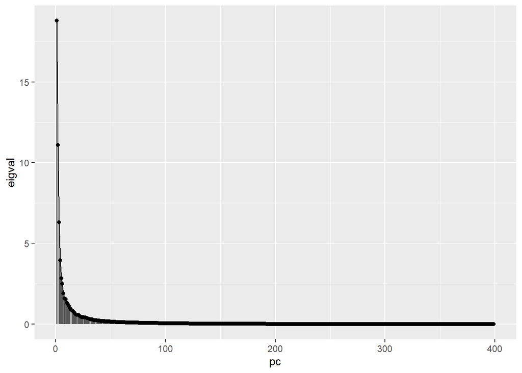

```r
# 스크리 도표 그리기 (ggbiplot)
library(ggfortify)
ggplot(vrexp2, aes(x=pc, y=eigval))+
  geom_col()+geom_point()+ geom_line()
```

=> 아이겐 값이 1이 넘는 주성분만 사용할 때는 주성분 개수는 12개 이다.주성분 12개를 사용했을 때 전체의 68 %를 설명하고 있다. (이미지 압축 효과)

=> 누적 비율이 80% 가 넘는 주성분을 사용할 때는 주성분 개수가 27개, 90% 이상일 때는 주성분 개수가 66개 이다. 이미지를 주성분 분석했을 때에는 “이미지 압축” 효과가 있다. 즉, 원본 (주성분 분석 x) 에 비해 원본의 특징이 부각되지 않는 흐릿한 사진이 보이게 되는 것이다.

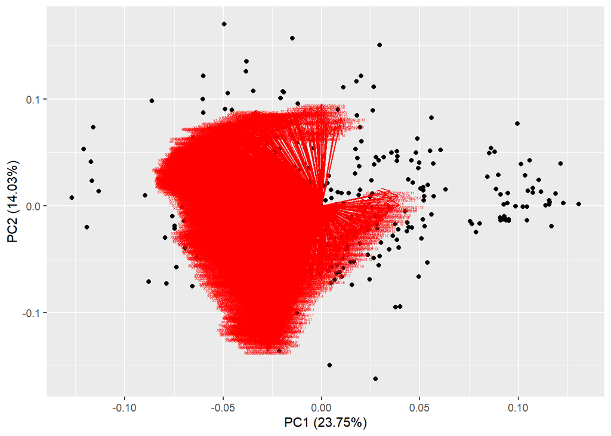

```r
# biplot 그리기

autoplot(Mprcomp_olivetti, data=olivetti,
         loadings=TRUE, loadings.label=TRUE,
         loadings.label.size=1,loadings.label.vjust=1)
```

=> 이미지는 해석이 쉽지 않다.